# Homework 2 - Chicago Crime Analysis

### Question 2:

Another way to find the pattern in crime statistics is how they are changing over time. Create a chart similar to the above to show how the total count of incidents changes annually. Then comment on the pattern you observe from the chart.

```r
# Your code goes here
```

### Question 3:

Since majority of incidents are among thefts, batteries, criminal damages and narcotics, we are asked to plot another chart to present their annual changes from 2001 to present. Comment on the similarity/difference between this chart and the one from question 2.

```r
# Your code goes here
```

### Question 4:

A lot of national attentions on Chicago have been place on the homicide rates, especially after President Trump expressed his wish to intervene. You’re asked to create a chart on homicides in Chicago and verify whether there was a spike in homicides rate in 2016.

*Hint:* In the MongoDB aggregate framework, `$match` operator allows us to filter the documents of interest. For example, if you wish to filter out the homicide cases, the operation `{"$match": {"Primary Type" : "HOMICIDE"}}` returns only homicide cases.

```r
# Your code goes here
```

### Question 5:

In the last decade, government’s response to this societal problem has increased, both in effort and in effectiveness. The Illinois Domestic Violence Act of 1986 ushered in a new era for our state. Recent Supreme Court rulings have put more “teeth” into the law by effectively mandating that law enforcement act to protect victims of domestic abuse.

In this part, we are exploring the pattern of domestic-related crimes. In the data set, the field `Domestic` indicates whether the corresponding incidents were domestic-related as defined by the Illinois Domestic Violence Act.

From 2001 to present, the total count of domestic-related incidents is:

```r
crimes$count('{"Domestic" : "true"}')
```

```
[1] 877867
```

The breakdown in domestic-related incidents is:

```r
crimes$aggregate('[ {"$match":{"Domestic" : "true"}},
                 {"$group": {"_id" : "$Primary Type",
                             "Count": {"$sum" : 1}}},
                 {"$sort" :{"Count" : -1}},
                 {"$limit": 10}]')
```

```
                          _id  Count
1                     BATTERY 519555
2               OTHER OFFENSE 121557
3                     ASSAULT  90764
4             CRIMINAL DAMAGE  58877
5                       THEFT  33450
6  OFFENSE INVOLVING CHILDREN  23131
7           CRIMINAL TRESPASS   6200
8                     ROBBERY   4095
9         CRIM SEXUAL ASSAULT   3574
10         DECEPTIVE PRACTICE   2981
```

How do domestic-related incidents change over time? Create a chart to present it.

```r
# Your code goes here
```

There are many different patterns of domestic crimes. For example, are they common in certain days/hours/months? While the information about time and date are available in the data set, extracting such information might be difficult. MongoDB has several operators helping to extract such information from its `Date` format, to which we need to convert the field `Date`.

For example, we can compute the total incidents by day of the week as:

```r
week_day
```

```
  _id  Count
1   1 147104
2   2 125994
3   3 116963
4   4 116307
5   5 115540
6   6 117576
7   7 140760
```

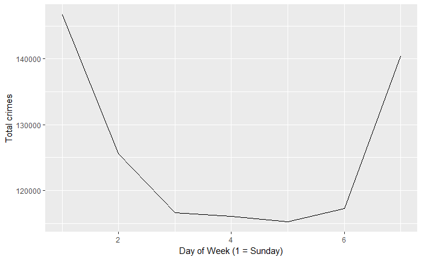

### Question 6:

The chart shows that domestic crimes are common over the weekend than in weekdays. It is interesting, but what could be the reason? It is hard to say. However, in this question, you’re asked to look at the pattern not only by day of the week but also for each day by hour.

```r
# Your code goes here.
```

### Question 7:

As you found out about the type of crimes, theft, battery, criminal damage and narcotics are among the most frequently crimes committed. Can you generate plots by day and hour for each of those.

```r
# Your code goes here
```

### Question 8:

I am curious about the pattern of crimes and whether they are associated with temperature? While it is possible to query historic weather data, it is time-comsuming. However, we can use month of the year as a proxy for the temperature. What can you say about such pattern? Is it true that crimes are more frequently committed during the warm months? Justify your answer with data from Chicago crime dataset.